# Herpailurus yagouaroundi Variable Selection

Author

Florencia Grattarola

Published

October 1, 2024

Variable Selection for *Herpailurus yagouaroundi*, using the data generated in the previous step.

- R Libraries

```r
library(knitr)
library(dismo)
library(gbm)
library(randomForest)
library(ranger) # for the Random Forest
library(terra)
terraOptions(tempdir='big_data/temp')
library(sf)
library(tidyverse)
```

- `bio1`: Annual Mean Temperature, from Bioclimatic variables (WorldClim V2.1)
- `bio2`: Mean Diurnal Range (Mean of monthly (max temp - min temp)), from Bioclimatic variables (WorldClim V2.1)
- `bio3`: Isothermality (BIO2/BIO7) (×100), from Bioclimatic variables (WorldClim V2.1)
- `bio4`: Temperature Seasonality (standard deviation ×100), from Bioclimatic variables (WorldClim V2.1)
- `bio5`: Max Temperature of Warmest Month, from Bioclimatic variables (WorldClim V2.1)
- `bio6`: Min Temperature of Coldest Month, from Bioclimatic variables (WorldClim V2.1)
- `bio7`: Temperature Annual Range (BIO5-BIO6), from Bioclimatic variables (WorldClim V2.1)
- `bio8`: Mean Temperature of Wettest Quarter, from Bioclimatic variables (WorldClim V2.1)
- `bio9`: Mean Temperature of Driest Quarter, from Bioclimatic variables (WorldClim V2.1)
- `bio10`: Mean Temperature of Warmest Quarter, from Bioclimatic variables (WorldClim V2.1)
- `bio11`: Mean Temperature of Coldest Quarter, from Bioclimatic variables (WorldClim V2.1)
- `bio12`: Annual Precipitation, from Bioclimatic variables (WorldClim V2.1)
- `bio13`: Precipitation of Wettest Month, from Bioclimatic variables (WorldClim V2.1)
- `bio14`: Precipitation of Driest Month, from Bioclimatic variables (WorldClim V2.1)
- `bio15`: Precipitation Seasonality (Coefficient of Variation), from Bioclimatic variables (WorldClim V2.1)
- `bio16`: Precipitation of Wettest Quarter, from Bioclimatic variables (WorldClim V2.1)
- `bio17`: Precipitation of Driest Quarter, from Bioclimatic variables (WorldClim V2.1)
- `bio18`: Precipitation of Warmest Quarter, from Bioclimatic variables (WorldClim V2.1)
- `bio19`: Precipitation of Coldest Quarter, from Bioclimatic variables (WorldClim V2.1)
- `elev`: Elevation (WorldClim V2.1 SRTM elevation data), from Bioclimatic variables (WorldClim V2.1)
- `urban`: Urban and Built-up Lands, from Land cover LC1 (MODIS TERRA LandCover_Type_Yearly_500m (MCD12Q1))
- `barren`: Barren, from Land cover LC1 (MODIS TERRA LandCover_Type_Yearly_500m (MCD12Q1))
- `water`: Water Bodies, from Land cover LC1 (MODIS TERRA LandCover_Type_Yearly_500m (MCD12Q1))
- `savanna`: Savannas, from Land cover LC1 (MODIS TERRA LandCover_Type_Yearly_500m (MCD12Q1))
- `woodysavanna`: Woody savannas, from Land cover LC1 (MODIS TERRA LandCover_Type_Yearly_500m (MCD12Q1))
- `wetland`: Permanent Wetlands, from Land cover LC1 (MODIS TERRA LandCover_Type_Yearly_500m (MCD12Q1))
- `grass`: Grasslands, from Land cover LC1 (MODIS TERRA LandCover_Type_Yearly_500m (MCD12Q1))
- `npp`: Net Primary Production (NPP) (MODIS TERRA Net_PP_GapFil_Yearly_500m (M*D17A3HGF))
- `tree`: Percentage of Tree Cover, from Vegetation Continuous Fields (MODIS TERRA Veg_Cont_Fields_Yearly_250m (MOD44B))
- `nontree`: Percentage of No Tree Cover, from Vegetation Continuous Fields (MODIS TERRA Veg_Cont_Fields_Yearly_250m (MOD44B))
- `nonveg`: Percentage of Non Tree Vegetation Cover, from Vegetation Continuous Fields (MODIS TERRA Veg_Cont_Fields_Yearly_250m (MOD44B))

```r
bio <- rast('big_data/bio_high.tif')
elev <- rast('big_data/elev_high.tif')
urban <- rast('big_data/urban_high.tif') %>% resample(., elev)
barren  <- rast('big_data/barren_high.tif') %>% resample(., elev)
water <- rast('big_data/water_high.tif') %>% resample(., elev)
savanna <- rast('big_data/savanna_high.tif') %>% resample(., elev)
woodysavanna <- rast('big_data/woodysavanna_high.tif') %>% resample(., elev)
wetland <- rast('big_data/wetland_high.tif') %>% resample(., elev)
grass <- rast('big_data/grass_high.tif') %>% resample(., elev)
npp <- rast('big_data/npp_high.tif') %>% resample(., elev)
names(npp) <- 'npp'
tree <- rast('big_data/tree_high.tif') %>% resample(., elev)
nontree <- rast('big_data/nontree_high.tif') %>% resample(., elev)
nonveg <- rast('big_data/nonveg_high.tif') %>% resample(., elev)

env <- c(bio, elev, urban, barren, water,
         savanna, woodysavanna, wetland,
         grass, npp, tree, nontree, nonveg) %>% scale()

rm(bio, elev, urban, barren, water,
         savanna, woodysavanna, wetland,
         grass, npp, tree, nontree, nonveg)

gc()
```

## Herpailurus yagouaroundi’ preferences

We will use the data from both periods

```r
PA_time1 <- readRDS('data/species_POPA_data/PA_hyagouaroundi_time1_blobs.rds')%>% ungroup()
PA_time2 <- readRDS('data/species_POPA_data/PA_hyagouaroundi_time2_blobs.rds')%>% ungroup()

PA_time1 %>% st_drop_geometry() %>% head() %>% kable()
```

| ID | presence | temporalSpan | effort | blobArea |
| --- | --- | --- | --- | --- |
| 1 | 0 | 1365 days | 1043 | 241873943 [m^2] |
| 2 | 1 | 1769 days | 2404 | 537081878 [m^2] |
| 3 | 1 | 6222 days | 11078 | 2241827859 [m^2] |
| 4 | 1 | 720 days | 1291 | 162791738 [m^2] |
| 5 | 0 | 1769 days | 1779 | 756798182 [m^2] |
| 6 | 1 | 304 days | 3300 | 19990863 [m^2] |

```r
PA_time2 %>% st_drop_geometry() %>% head() %>% kable()
```

| ID | presence | temporalSpan | effort | blobArea |
| --- | --- | --- | --- | --- |
| 1 | 0 | 510 days | 11095 | 2.229446e+09 [m^2] |
| 2 | 1 | 150 days | 12276 | 1.542295e+03 [m^2] |
| 3 | 1 | 407 days | 1585 | 1.049520e-01 [m^2] |
| 4 | 1 | 869 days | 1440 | 7.494574e+01 [m^2] |
| 5 | 1 | 70 days | 400 | 2.546836e+01 [m^2] |
| 6 | 1 | 756 days | 7164 | 2.398904e-01 [m^2] |

Presence-absence data for the second period

### Preparation of data for the tests

```r
# combine pre and pos datasets
PA.data <- st_join(PA_time1, PA_time2 %>% dplyr::select(presence), left = T) %>%
  group_by(ID) %>%
  mutate(presence=max(presence.x, presence.y, na.rm = T))

# calculate area, coordinates, and extract env predictors for each blob
PA.coords <- st_coordinates(st_centroid(PA.data)) %>% as_tibble()
PA.area <- as.numeric(PA.data$blobArea)

PA.env <- terra::extract(x = env, y = vect(PA.data),
                         fun = mean, rm.na=T) %>%
  mutate(across(where(is.numeric), ~ifelse(is.nan(.), NA, .)))

## the data
PA <- data.frame(PA.coords,
                 area = PA.area,
                 presabs = PA.data$presence,
                 env = PA.env)
```

### Correlation between variables

```r
PA %>% filter(!if_any(everything(), is.na)) %>% dplyr::select(-c(1:5)) %>% cor() %>% kable()
```

|  | env.bio_1 | env.bio_2 | env.bio_3 | env.bio_4 | env.bio_5 | env.bio_6 | env.bio_7 | env.bio_8 | env.bio_9 | env.bio_10 | env.bio_11 | env.bio_12 | env.bio_13 | env.bio_14 | env.bio_15 | env.bio_16 | env.bio_17 | env.bio_18 | env.bio_19 | env.elev | env.urban | env.barren | env.water | env.savanna | env.woodysavanna | env.wetland | env.grass | env.npp | env.tree | … |
| --- | --- | --- | --- | --- | --- | --- | --- | --- | --- | --- | --- | --- | --- | --- | --- | --- | --- | --- | --- | --- | --- | --- | --- | --- | --- | --- | --- | --- | --- | --- |
| env.bio_1 | 1.0000000 | 0.9296441 | 0.9683961 | 0.2245524 | 0.3650713 | -0.0974913 | 0.2598362 | 0.4133726 | -0.1088920 | -0.2171595 | 0.1956382 | -0.2049978 | 0.6915905 | -0.6813646 | 0.8361199 | 0.9132283 | -0.5533539 | 0.8696582 | 0.9064849 | -0.6579087 | -0.2201133 | -0.0977410 | 0.2893823 | -0.0024650 | 0.0280840 | 0.1505896 | -0.1029622 | -0.5423448 | 0.2241057 | … |
| env.bio_2 | 0.9296441 | 1.0000000 | 0.8201186 | 0.1070940 | 0.1263286 | -0.0188141 | 0.1075105 | 0.1704404 | -0.0270968 | -0.2734955 | 0.1868085 | -0.1426003 | 0.4381869 | -0.3771548 | 0.9194218 | 0.7840670 | -0.3309997 | 0.8667005 | 0.7893311 | -0.8088566 | -0.2416197 | -0.1129521 | 0.2673516 | 0.0269795 | 0.0437261 | 0.2158389 | -0.1911302 | -0.5957826 | 0.2394162 | … |
| env.bio_3 | 0.9683961 | 0.8201186 | 1.0000000 | 0.3145337 | 0.4841739 | -0.0902739 | 0.3019023 | 0.5416489 | -0.1019188 | -0.2194668 | 0.2423853 | -0.2688312 | 0.8182906 | -0.8385889 | 0.7284579 | 0.9531144 | -0.6805953 | 0.7863656 | 0.9351986 | -0.5387853 | -0.1778445 | -0.0766928 | 0.3146130 | -0.0212454 | 0.0151050 | 0.0830030 | -0.0941385 | -0.4287304 | 0.2510269 | … |
| env.bio_4 | 0.2245524 | 0.1070940 | 0.3145337 | 1.0000000 | 0.7642354 | 0.7267723 | -0.4858212 | 0.7801517 | 0.7257054 | 0.3332077 | 0.7446606 | -0.5595604 | 0.5005643 | -0.4148608 | -0.0696912 | 0.4462757 | -0.6123342 | 0.0898132 | 0.3375557 | -0.2702648 | 0.0226405 | -0.1373670 | 0.3077364 | -0.4152737 | -0.1495779 | -0.1146293 | -0.1512988 | 0.2195306 | 0.5598284 | … |
| env.bio_5 | 0.3650713 | 0.1263286 | 0.4841739 | 0.7642354 | 1.0000000 | 0.1933128 | 0.1171199 | 0.9784670 | 0.1835373 | 0.3598166 | 0.4346112 | -0.3516015 | 0.6733107 | -0.6659381 | -0.0034808 | 0.5031871 | -0.6367356 | 0.2330854 | 0.4266622 | -0.0644255 | 0.0457209 | -0.1574742 | 0.2459976 | -0.3587865 | -0.0619659 | -0.1330635 | 0.1157962 | 0.0741961 | 0.3196852 | … |
| env.bio_6 | -0.0974913 | -0.0188141 | -0.0902739 | 0.7267723 | 0.1933128 | 1.0000000 | -0.8648488 | 0.1913458 | 0.9965494 | 0.1837194 | 0.7740640 | -0.5300579 | 0.0892696 | 0.1186764 | -0.1996677 | 0.1249108 | -0.3001855 | -0.1378122 | 0.0099549 | -0.3037383 | -0.0295608 | -0.0459756 | 0.2895092 | -0.3454885 | -0.1352915 | -0.0004524 | -0.3242425 | 0.2813411 | 0.5902548 | … |
| env.bio_7 | 0.2598362 | 0.1075105 | 0.3019023 | -0.4858212 | 0.1171199 | -0.8648488 | 1.0000000 | 0.1220172 | -0.8782263 | -0.1345391 | -0.5756748 | 0.4185941 | 0.2440087 | -0.3840589 | 0.2496259 | 0.1033349 | 0.0482055 | 0.2443413 | 0.1945389 | 0.2985608 | 0.0225795 | -0.0051382 | -0.1606119 | 0.2264854 | 0.1850820 | -0.0391527 | 0.2617882 | -0.2260104 | -0.4273476 | … |
| env.bio_8 | 0.4133726 | 0.1704404 | 0.5416489 | 0.7801517 | 0.9784670 | 0.1913458 | 0.1220172 | 1.0000000 | 0.1819016 | 0.3180265 | 0.4533295 | -0.4161798 | 0.7057661 | -0.7191324 | 0.0339333 | 0.5715997 | -0.6962200 | 0.2568050 | 0.4948495 | -0.1003456 | 0.0642175 | -0.1537781 | 0.2693363 | -0.3170436 | -0.0375880 | -0.1611847 | 0.0346935 | 0.0835534 | 0.3395489 | … |
| env.bio_9 | -0.1088920 | -0.0270968 | -0.1019188 | 0.7257054 | 0.1835373 | 0.9965494 | -0.8782263 | 0.1819016 | 1.0000000 | 0.1840244 | 0.7748265 | -0.5272262 | 0.0770351 | 0.1295226 | -0.2067214 | 0.1137978 | -0.2912206 | -0.1496451 | -0.0013905 | -0.3043808 | -0.0294760 | -0.0483047 | 0.2836730 | -0.3479909 | -0.1389403 | -0.0005642 | -0.3307918 | 0.2925463 | 0.5897787 | … |
| env.bio_10 | -0.2171595 | -0.2734955 | -0.2194668 | 0.3332077 | 0.3598166 | 0.1837194 | -0.1345391 | 0.3180265 | 0.1840244 | 1.0000000 | -0.1092807 | -0.1343382 | -0.0811383 | 0.1021154 | -0.4429341 | -0.1997582 | -0.0648619 | -0.0145843 | -0.3385074 | 0.1685297 | 0.2582501 | -0.1263971 | -0.1456711 | -0.2570984 | 0.0182359 | -0.0638922 | 0.0956723 | 0.2583383 | -0.0288362 | … |
| env.bio_11 | 0.1956382 | 0.1868085 | 0.2423853 | 0.7446606 | 0.4346112 | 0.7740640 | -0.5756748 | 0.4533295 | 0.7748265 | -0.1092807 | 1.0000000 | -0.6357030 | 0.4318087 | -0.2273811 | -0.0001334 | 0.4547914 | -0.5733417 | 0.0224191 | 0.3619071 | -0.3934250 | -0.0896497 | -0.0345635 | 0.4128212 | -0.3398411 | -0.0967487 | -0.0340330 | -0.2794210 | 0.1254955 | 0.6191653 | … |
| env.bio_12 | -0.2049978 | -0.1426003 | -0.2688312 | -0.5595604 | -0.3516015 | -0.5300579 | 0.4185941 | -0.4161798 | -0.5272262 | -0.1343382 | -0.6357030 | 1.0000000 | -0.3325137 | 0.3049036 | 0.1966475 | -0.5250598 | 0.8023981 | -0.0861157 | -0.3309889 | 0.3821173 | -0.0890791 | 0.0167159 | -0.4386322 | 0.3434812 | 0.0467406 | -0.0727980 | 0.3469681 | -0.1737652 | -0.5951082 | … |
| env.bio_13 | 0.6915905 | 0.4381869 | 0.8182906 | 0.5005643 | 0.6733107 | 0.0892696 | 0.2440087 | 0.7057661 | 0.0770351 | -0.0811383 | 0.4318087 | -0.3325137 | 1.0000000 | -0.9118016 | 0.3261453 | 0.8255327 | -0.8073928 | 0.4789765 | 0.7641805 | -0.2005044 | -0.1124490 | -0.0021708 | 0.3366226 | -0.1551412 | -0.0112436 | -0.0695311 | -0.0158723 | -0.1472418 | 0.2873553 | … |
| env.bio_14 | -0.6813646 | -0.3771548 | -0.8385889 | -0.4148608 | -0.6659381 | 0.1186764 | -0.3840589 | -0.7191324 | 0.1295226 | 0.1021154 | -0.2273811 | 0.3049036 | -0.9118016 | 1.0000000 | -0.3065325 | -0.8003439 | 0.7896644 | -0.4447706 | -0.7650724 | 0.1075528 | 0.0491570 | 0.0151001 | -0.2590556 | 0.0693126 | 0.0098816 | 0.0774311 | -0.0168947 | 0.1143688 | -0.1926304 | … |
| env.bio_15 | 0.8361199 | 0.9194218 | 0.7284579 | -0.0696912 | -0.0034808 | -0.1996677 | 0.2496259 | 0.0339333 | -0.2067214 | -0.4429341 | -0.0001334 | 0.1966475 | 0.3261453 | -0.3065325 | 1.0000000 | 0.6102757 | -0.0543381 | 0.7628378 | 0.7072778 | -0.6630353 | -0.2740025 | -0.1002805 | 0.1226871 | 0.1672372 | 0.0462821 | 0.1653903 | -0.0906072 | -0.6102193 | 0.0503882 | … |
| env.bio_16 | 0.9132283 | 0.7840670 | 0.9531144 | 0.4462757 | 0.5031871 | 0.1249108 | 0.1033349 | 0.5715997 | 0.1137978 | -0.1997582 | 0.4547914 | -0.5250598 | 0.8255327 | -0.8003439 | 0.6102757 | 1.0000000 | -0.8241800 | 0.7110844 | 0.9320639 | -0.6213394 | -0.1491519 | -0.0630686 | 0.4173645 | -0.1202489 | 0.0029894 | 0.1034344 | -0.2159955 | -0.3303117 | 0.4202314 | … |
| env.bio_17 | -0.5533539 | -0.3309997 | -0.6805953 | -0.6123342 | -0.6367356 | -0.3001855 | 0.0482055 | -0.6962200 | -0.2912206 | -0.0648619 | -0.5733417 | 0.8023981 | -0.8073928 | 0.7896644 | -0.0543381 | -0.8241800 | 1.0000000 | -0.3509483 | -0.6692034 | 0.3091761 | -0.0078816 | 0.0078058 | -0.4383634 | 0.2711251 | 0.0293186 | -0.0121391 | 0.2074795 | -0.0198950 | -0.4936629 | … |
| env.bio_18 | 0.8696582 | 0.8667005 | 0.7863656 | 0.0898132 | 0.2330854 | -0.1378122 | 0.2443413 | 0.2568050 | -0.1496451 | -0.0145843 | 0.0224191 | -0.0861157 | 0.4789765 | -0.4447706 | 0.7628378 | 0.7110844 | -0.3509483 | 1.0000000 | 0.6106291 | -0.5930138 | -0.1337635 | -0.0844168 | 0.1904426 | -0.0413308 | 0.0667723 | 0.1977084 | -0.0870639 | -0.5298813 | 0.1649284 | … |
| env.bio_19 | 0.9064849 | 0.7893311 | 0.9351986 | 0.3375557 | 0.4266622 | 0.0099549 | 0.1945389 | 0.4948495 | -0.0013905 | -0.3385074 | 0.3619071 | -0.3309889 | 0.7641805 | -0.7650724 | 0.7072778 | 0.9320639 | -0.6692034 | 0.6106291 | 1.0000000 | -0.5894832 | -0.2207150 | -0.0580746 | 0.3417830 | 0.0150607 | 0.0015716 | 0.0673108 | -0.1438877 | -0.4089540 | 0.2748842 | … |
| env.elev | -0.6579087 | -0.8088566 | -0.5387853 | -0.2702648 | -0.0644255 | -0.3037383 | 0.2985608 | -0.1003456 | -0.3043808 | 0.1685297 | -0.3934250 | 0.3821173 | -0.2005044 | 0.1075528 | -0.6630353 | -0.6213394 | 0.3091761 | -0.5930138 | -0.5894832 | 1.0000000 | 0.1776808 | 0.0973969 | -0.2664306 | 0.0973135 | 0.0062860 | -0.1804121 | 0.3347777 | 0.3623028 | -0.3968661 | … |
| env.urban | -0.2201133 | -0.2416197 | -0.1778445 | 0.0226405 | 0.0457209 | -0.0295608 | 0.0225795 | 0.0642175 | -0.0294760 | 0.2582501 | -0.0896497 | -0.0890791 | -0.1124490 | 0.0491570 | -0.2740025 | -0.1491519 | -0.0078816 | -0.1337635 | -0.2207150 | 0.1776808 | 1.0000000 | -0.0109690 | -0.0607542 | -0.0470701 | 0.0318901 | -0.0606497 | -0.0753713 | 0.1344147 | -0.0366332 | … |
| env.barren | -0.0977410 | -0.1129521 | -0.0766928 | -0.1373670 | -0.1574742 | -0.0459756 | -0.0051382 | -0.1537781 | -0.0483047 | -0.1263971 | -0.0345635 | 0.0167159 | -0.0021708 | 0.0151001 | -0.1002805 | -0.0630686 | 0.0078058 | -0.0844168 | -0.0580746 | 0.0973969 | -0.0109690 | 1.0000000 | -0.0116914 | -0.0361940 | -0.0154035 | -0.0116054 | -0.0235731 | -0.0790421 | -0.0543190 | … |
| env.water | 0.2893823 | 0.2673516 | 0.3146130 | 0.3077364 | 0.2459976 | 0.2895092 | -0.1606119 | 0.2693363 | 0.2836730 | -0.1456711 | 0.4128212 | -0.4386322 | 0.3366226 | -0.2590556 | 0.1226871 | 0.4173645 | -0.4383634 | 0.1904426 | 0.3417830 | -0.2664306 | -0.0607542 | -0.0116914 | 1.0000000 | -0.1898651 | -0.0920385 | 0.1375010 | -0.1324898 | -0.3658775 | 0.7287007 | … |
| env.savanna | -0.0024650 | 0.0269795 | -0.0212454 | -0.4152737 | -0.3587865 | -0.3454885 | 0.2264854 | -0.3170436 | -0.3479909 | -0.2570984 | -0.3398411 | 0.3434812 | -0.1551412 | 0.0693126 | 0.1672372 | -0.1202489 | 0.2711251 | -0.0413308 | 0.0150607 | 0.0973135 | -0.0470701 | -0.0361940 | -0.1898651 | 1.0000000 | -0.1167850 | -0.1579102 | -0.1249173 | -0.1437237 | -0.4725033 | … |
| env.woodysavanna | 0.0280840 | 0.0437261 | 0.0151050 | -0.1495779 | -0.0619659 | -0.1352915 | 0.1850820 | -0.0375880 | -0.1389403 | 0.0182359 | -0.0967487 | 0.0467406 | -0.0112436 | 0.0098816 | 0.0462821 | 0.0029894 | 0.0293186 | 0.0667723 | 0.0015716 | 0.0062860 | 0.0318901 | -0.0154035 | -0.0920385 | -0.1167850 | 1.0000000 | -0.0847233 | -0.1104016 | 0.0006886 | -0.0777231 | … |
| env.wetland | 0.1505896 | 0.2158389 | 0.0830030 | -0.1146293 | -0.1330635 | -0.0004524 | -0.0391527 | -0.1611847 | -0.0005642 | -0.0638922 | -0.0340330 | -0.0727980 | -0.0695311 | 0.0774311 | 0.1653903 | 0.1034344 | -0.0121391 | 0.1977084 | 0.0673108 | -0.1804121 | -0.0606497 | -0.0116054 | 0.1375010 | -0.1579102 | -0.0847233 | 1.0000000 | -0.1258117 | -0.3612828 | 0.2205404 | … |
| env.grass | -0.1029622 | -0.1911302 | -0.0941385 | -0.1512988 | 0.1157962 | -0.3242425 | 0.2617882 | 0.0346935 | -0.3307918 | 0.0956723 | -0.2794210 | 0.3469681 | -0.0158723 | -0.0168947 | -0.0906072 | -0.2159955 | 0.2074795 | -0.0870639 | -0.1438877 | 0.3347777 | -0.0753713 | -0.0235731 | -0.1324898 | -0.1249173 | -0.1104016 | -0.1258117 | 1.0000000 | -0.1337146 | -0.4646464 | … |
| env.npp | -0.5423448 | -0.5957826 | -0.4287304 | 0.2195306 | 0.0741961 | 0.2813411 | -0.2260104 | 0.0835534 | 0.2925463 | 0.2583383 | 0.1254955 | -0.1737652 | -0.1472418 | 0.1143688 | -0.6102193 | -0.3303117 | -0.0198950 | -0.5298813 | -0.4089540 | 0.3623028 | 0.1344147 | -0.0790421 | -0.3658775 | -0.1437237 | 0.0006886 | -0.3612828 | -0.1337146 | 1.0000000 | -0.0468240 | … |
| env.tree | 0.2241057 | 0.2394162 | 0.2510269 | 0.5598284 | 0.3196852 | 0.5902548 | -0.4273476 | 0.3395489 | 0.5897787 | -0.0288362 | 0.6191653 | -0.5951082 | 0.2873553 | -0.1926304 | 0.0503882 | 0.4202314 | -0.4936629 | 0.1649284 | 0.2748842 | -0.3968661 | -0.0366332 | -0.0543190 | 0.7287007 | -0.4725033 | -0.0777231 | 0.2205404 | -0.4646464 | -0.0468240 | 1.0000000 | … |
| env.nontree | 0.1944363 | 0.2026016 | 0.1763470 | -0.0677038 | 0.0073694 | -0.0208942 | 0.0504557 | -0.0039337 | -0.0290542 | -0.1901205 | 0.0444401 | -0.0668483 | 0.1459596 | -0.0852376 | 0.1630034 | 0.1793595 | -0.1095460 | 0.1344020 | 0.1941162 | -0.0874815 | -0.0745566 | -0.0802550 | 0.7473932 | 0.1212126 | -0.1006558 | 0.2479464 | 0.2073061 | -0.5293037 | 0.2718941 | … |
| env.nonveg | 0.3216861 | 0.3128536 | 0.3326884 | 0.2675771 | 0.2150625 | 0.2560326 | -0.1488980 | 0.2253595 | 0.2499643 | -0.1873301 | 0.3673542 | -0.3700583 | 0.3206495 | -0.2445389 | 0.1918470 | 0.4141109 | -0.3848206 | 0.2359080 | 0.3490410 | -0.3009313 | -0.0958183 | 0.0973328 | 0.9149495 | -0.2018991 | -0.1058182 | 0.2796946 | -0.1003525 | -0.4653541 | 0.7398183 | … |

## Variable Importance analyses

### Simple GLM

```r
presabs.glm <- PA %>%
  dplyr::select(-c(1,2,3,5)) %>%
  filter(!is.na(env.elev)&!is.na(env.bio_1))

glm.full<- glm(presabs ~.,
               family = "binomial",
               data = presabs.glm)

summary(glm.full)
```

```
Call:
glm(formula = presabs ~ ., family = "binomial", data = presabs.glm)

Deviance Residuals:
    Min       1Q   Median       3Q      Max
-3.0044  -0.5718  -0.3831   0.4691   2.5916

Coefficients:
                   Estimate Std. Error z value Pr(>|z|)
(Intercept)      -1.074e+02  1.377e+02  -0.780 0.435413
env.bio_1         3.619e+00  7.514e+00   0.482 0.630079
env.bio_2         1.475e+01  8.510e+00   1.734 0.082963 .
env.bio_3        -2.370e+01  1.431e+01  -1.656 0.097784 .
env.bio_4         2.236e+00  1.827e+00   1.224 0.221006
env.bio_5        -2.494e+00  1.582e+00  -1.576 0.115064
env.bio_6        -2.121e+00  1.565e+00  -1.355 0.175417
env.bio_7         9.541e-01  5.486e-01   1.739 0.082017 .
env.bio_8         1.763e+00  2.123e+00   0.830 0.406267
env.bio_9         2.320e+00  2.008e+00   1.155 0.247959
env.bio_10       -4.717e-01  4.438e-01  -1.063 0.287782
env.bio_11       -1.199e+00  6.246e-01  -1.920 0.054832 .
env.bio_12        8.862e+00  2.041e+00   4.342 1.41e-05 ***
env.bio_13       -2.514e+00  1.310e+00  -1.919 0.054971 .
env.bio_14       -5.102e+00  8.250e+00  -0.618 0.536297
env.bio_15       -1.318e+06  1.220e+06  -1.080 0.280105
env.bio_16        2.209e+06  2.045e+06   1.080 0.280105
env.bio_17        1.877e+06  1.738e+06   1.080 0.280109
env.bio_18       -5.898e-02  9.893e-01  -0.060 0.952459
env.bio_19        1.760e+00  1.178e+00   1.493 0.135399
env.elev          9.756e-01  9.652e-01   1.011 0.312122
env.urban         1.109e+00  2.924e-01   3.794 0.000148 ***
env.barren       -5.340e+02  6.949e+02  -0.768 0.442220
env.water        -1.892e-01  3.087e-01  -0.613 0.540058
env.savanna      -1.701e-01  2.392e-01  -0.711 0.477059
env.woodysavanna  4.208e-01  2.585e-01   1.628 0.103452
env.wetland      -1.179e-01  1.614e-01  -0.730 0.465351
env.grass        -4.654e-01  3.519e-01  -1.323 0.185952
env.npp           1.078e+00  3.402e-01   3.170 0.001526 **
env.tree          7.606e-02  5.639e-01   0.135 0.892698
env.nontree      -2.874e-02  5.507e-01  -0.052 0.958382
env.nonveg        2.627e-01  6.971e-01   0.377 0.706228
---
Signif. codes:  0 '***' 0.001 '**' 0.01 '*' 0.05 '.' 0.1 ' ' 1

(Dispersion parameter for binomial family taken to be 1)

    Null deviance: 650.23  on 558  degrees of freedom
Residual deviance: 440.38  on 527  degrees of freedom
AIC: 504.38

Number of Fisher Scoring iterations: 14
```

```r
step(glm.full) # step might not work with gam so glm
```

```
Start:  AIC=504.38
presabs ~ env.bio_1 + env.bio_2 + env.bio_3 + env.bio_4 + env.bio_5 +
    env.bio_6 + env.bio_7 + env.bio_8 + env.bio_9 + env.bio_10 +
    env.bio_11 + env.bio_12 + env.bio_13 + env.bio_14 + env.bio_15 +
    env.bio_16 + env.bio_17 + env.bio_18 + env.bio_19 + env.elev +
    env.urban + env.barren + env.water + env.savanna + env.woodysavanna +
    env.wetland + env.grass + env.npp + env.tree + env.nontree +
    env.nonveg

                   Df Deviance    AIC
- env.nontree       1   440.38 502.38
- env.bio_18        1   440.38 502.38
- env.tree          1   440.40 502.40
- env.nonveg        1   440.52 502.52
- env.bio_1         1   440.61 502.61
- env.water         1   440.76 502.76
- env.bio_14        1   440.77 502.77
- env.savanna       1   440.89 502.89
- env.wetland       1   441.01 503.01
- env.bio_8         1   441.07 503.07
- env.elev          1   441.44 503.44
- env.bio_10        1   441.53 503.53
- env.bio_17        1   441.55 503.55
- env.bio_16        1   441.55 503.55
- env.bio_15        1   441.55 503.55
- env.barren        1   441.69 503.69
- env.bio_9         1   441.71 503.71
- env.bio_4         1   441.90 503.90
- env.grass         1   442.17 504.17
- env.bio_6         1   442.20 504.20
<none>                  440.38 504.38
- env.bio_19        1   442.53 504.53
- env.bio_5         1   442.88 504.88
- env.woodysavanna  1   443.05 505.05
- env.bio_3         1   443.15 505.15
- env.bio_7         1   443.51 505.51
- env.bio_2         1   443.58 505.58
- env.bio_13        1   444.15 506.15
- env.bio_11        1   444.43 506.43
- env.npp           1   451.91 513.91
```

[output cut: 506 more lines]

```
- env.bio_5         1   452.78 482.78
- env.bio_11        1   452.96 482.96
- env.bio_13        1   454.30 484.30
- env.grass         1   454.75 484.75
- env.bio_19        1   455.32 485.32
- env.woodysavanna  1   455.49 485.49
- env.bio_7         1   455.65 485.65
- env.bio_4         1   455.66 485.66
- env.bio_16        1   459.97 489.97
- env.bio_3         1   461.05 491.05
- env.bio_12        1   474.41 504.41
- env.urban         1   482.00 512.00
- env.bio_15        1   484.60 514.60
- env.npp           1   493.31 523.31
- env.bio_2         1   494.44 524.44
```

```
Call:  glm(formula = presabs ~ env.bio_2 + env.bio_3 + env.bio_4 + env.bio_5 +
    env.bio_7 + env.bio_11 + env.bio_12 + env.bio_13 + env.bio_15 +
    env.bio_16 + env.bio_19 + env.urban + env.woodysavanna +
    env.grass + env.npp, family = "binomial", data = presabs.glm)

Coefficients:
     (Intercept)         env.bio_2         env.bio_3         env.bio_4
         -2.0968            9.6369          -10.2678            2.0632
       env.bio_5         env.bio_7        env.bio_11        env.bio_12
         -1.2283            1.0403           -0.6014            7.6178
      env.bio_13        env.bio_15        env.bio_16        env.bio_19
         -2.0964          -12.2221           15.3985            1.8305
       env.urban  env.woodysavanna         env.grass           env.npp
          1.0692            0.5192           -0.4754            1.2654

Degrees of Freedom: 558 Total (i.e. Null);  543 Residual
Null Deviance:      650.2
Residual Deviance: 450.5    AIC: 482.5
```

### Boosted regression trees

Boosted regression trees were fitted using packages: `gbm` and `dismo` — specifically the `gbm.step()` function (Hijmans et al., 2017)

```
 GBM STEP - version 2.9

Performing cross-validation optimisation of a boosted regression tree model
for NA and using a family of bernoulli
Using 565 observations and 31 predictors
creating 10 initial models of 50 trees

 folds are stratified by prevalence
total mean deviance =  1.1646
tolerance is fixed at  0.0012
ntrees resid. dev.
50    1.0486
now adding trees...
100   0.979
150   0.9358
```

[output cut: 40 more lines]

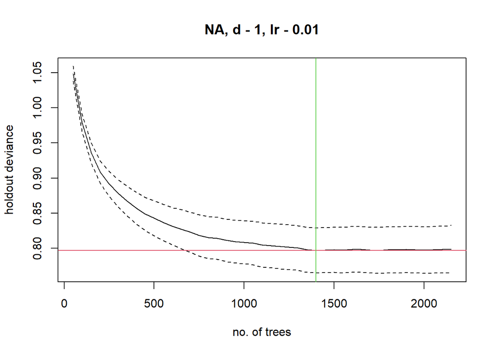

```
mean total deviance = 1.165
mean residual deviance = 0.627

estimated cv deviance = 0.797 ; se = 0.032

training data correlation = 0.742
cv correlation =  0.615 ; se = 0.029

training data AUC score = 0.924
cv AUC score = 0.855 ; se = 0.016

elapsed time -  0.1 minutes
```

```r
# cross-validation optimisation of a boosted regression tree model
brt <- gbm.step(data = PA,
                 gbm.x = 6:ncol(PA),
                 gbm.y = "presabs",
                 family = "bernoulli")
```

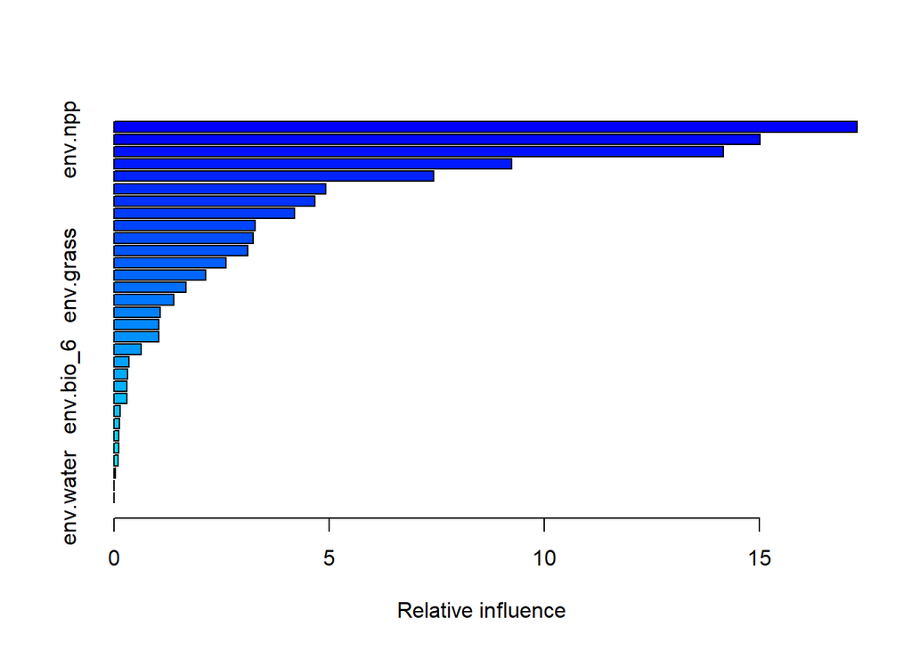

```
                              var     rel.inf
env.urban               env.urban 17.26861395
env.npp                   env.npp 15.01517364
env.woodysavanna env.woodysavanna 14.16072459
env.bio_10             env.bio_10  9.23881041
env.bio_7               env.bio_7  7.42318604
env.bio_15             env.bio_15  4.92413959
env.nonveg             env.nonveg  4.66377672
env.bio_13             env.bio_13  4.19897610
env.bio_9               env.bio_9  3.27987940
env.bio_19             env.bio_19  3.23337226
env.bio_8               env.bio_8  3.10326169
env.bio_4               env.bio_4  2.60126262
env.grass               env.grass  2.12961370
env.bio_5               env.bio_5  1.67426061
env.bio_16             env.bio_16  1.38605132
env.bio_11             env.bio_11  1.08115667
env.tree                 env.tree  1.04394678
env.bio_3               env.bio_3  1.04314388
env.bio_12             env.bio_12  0.63657303
env.bio_14             env.bio_14  0.35043006
env.savanna           env.savanna  0.32227466
env.bio_6               env.bio_6  0.30825035
env.bio_17             env.bio_17  0.30550370
env.wetland           env.wetland  0.13947752
env.bio_1               env.bio_1  0.12088078
env.elev                 env.elev  0.11976521
env.bio_2               env.bio_2  0.10446486
env.bio_18             env.bio_18  0.09746777
env.nontree           env.nontree  0.02556210
env.barren             env.barren  0.00000000
env.water               env.water  0.00000000
```

```r
summary(brt)
```

```r
variables_brt <- brt$contributions[1:6,] %>% pull(var)
#exploration of shape of relationships
#gbm.plot(brt, n.plots = 12, plot.layout=c(6, 2))
```

### Random forest

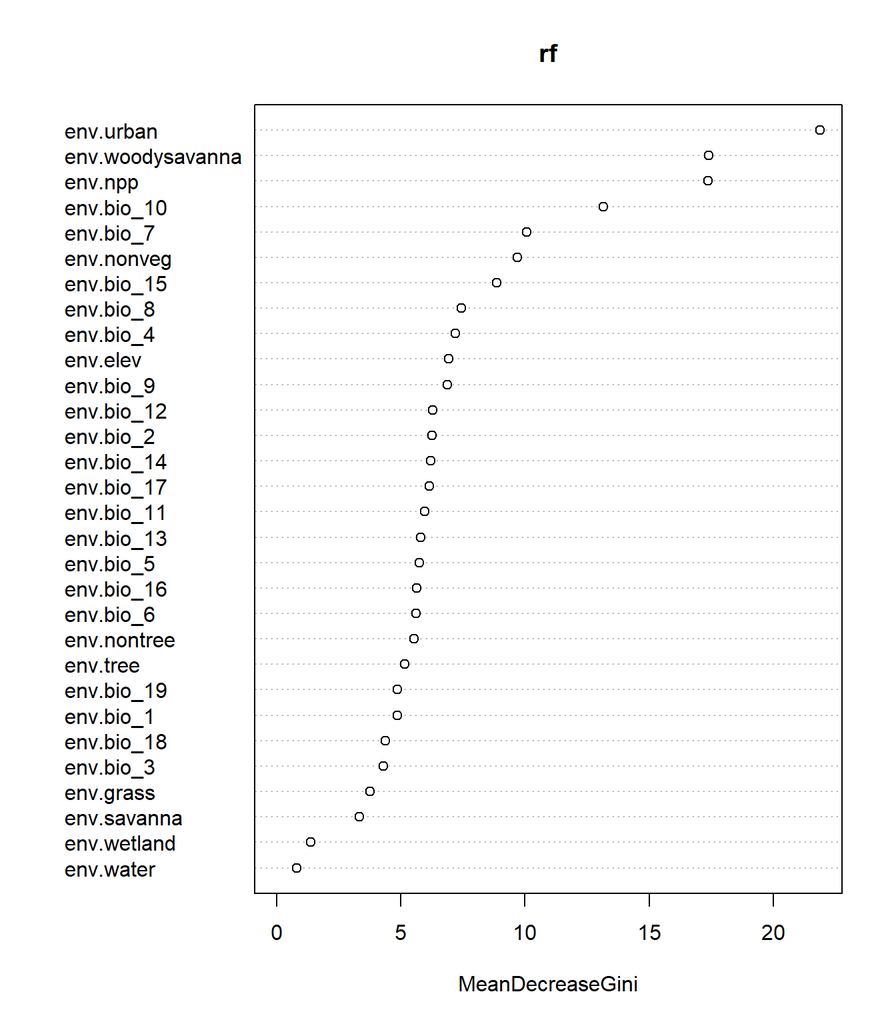

```r
presabs.rf <- PA %>%
  dplyr::select(-c(1,2,3,5)) %>%
  mutate(presabs = as.factor(presabs))

rf <- randomForest(presabs ~ .,
                   data=presabs.rf,
                   importance=T,
                   nperm=2, # two permutations per tree to estimate importance
                   na.action=na.omit,
                   mtry= 1/3*ncol(presabs.rf)-1)

varImpPlot(rf, type=2)
```

```r
variables_rf <- rf$importance %>% as_tibble(rownames = 'var') %>% arrange(desc(MeanDecreaseGini)) %>% head(n=6) %>% pull(var)
```

### Ranger

```r
presabs.ranger <- PA %>%
  dplyr::select(-c(1,2,3,5)) %>%
  filter(!if_any(everything(), is.na)) %>%
  mutate(presabs = as.factor(presabs))

## Learn the model:
ranger <- ranger(presabs ~ .,
                 data = presabs.ranger,
                 num.trees = 150,
                 mtry = 1/3*ncol(presabs.ranger)-1,
                 min.node.size = 5,
                 max.depth = NULL,
                 write.forest = TRUE,
                 importance = "impurity")


# Get the variable importance
importance(ranger)
```

```
       env.bio_1        env.bio_2        env.bio_3        env.bio_4
       3.8830559        6.1994138        4.5932245        7.3239922
       env.bio_5        env.bio_6        env.bio_7        env.bio_8
       7.2002733        5.2138027        8.9940396        5.5199000
       env.bio_9       env.bio_10       env.bio_11       env.bio_12
       6.1900716       11.3700848        5.3196636        5.6688179
      env.bio_13       env.bio_14       env.bio_15       env.bio_16
       5.5827974        5.8312823        8.2539183        4.7307267
      env.bio_17       env.bio_18       env.bio_19         env.elev
       6.2734100        4.9970425        5.0778873        7.3248256
       env.urban       env.barren        env.water      env.savanna
      21.0199917        0.2081271        0.9086772        3.6009138
env.woodysavanna      env.wetland        env.grass          env.npp
      15.5240477        1.7918203        3.3481191       17.6537944
        env.tree      env.nontree       env.nonveg
       5.2666224        4.7026054        8.3579938
```

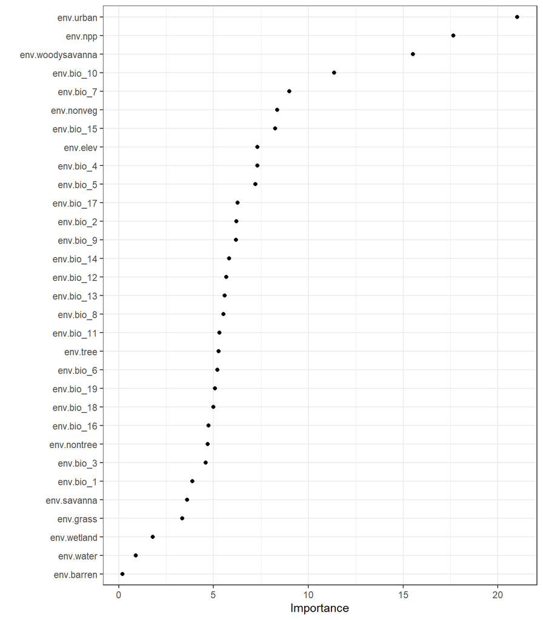

```r
importance(ranger) %>%
  as.data.frame(row.names = names(.)) %>%
  setNames(c("Importance")) %>%
  rownames_to_column("covariate") %>%
  # mutate(covariate = case_when(
  #   covariate == "env.bio_1" ~ "Annual Mean Temperature",
  # )) %>%
  ggplot(aes(x = Importance, y = reorder(covariate, Importance))) +
  ylab('')+
  geom_point() + theme_bw()
```

```r
variables_ranger <- importance(ranger) %>% as_tibble(rownames = 'var') %>% arrange(desc(value)) %>% head(n=6) %>% pull(var)
```

## Correlation

Correlation between the six more important variables detected.

- Boosted regression tree: env.urban, env.npp, env.woodysavanna, env.bio_10, env.bio_7, env.bio_15
- Random forest: env.urban, env.woodysavanna, env.npp, env.bio_10, env.bio_7, env.nonveg
- Ranger: env.urban, env.npp, env.woodysavanna, env.bio_10, env.bio_7, env.nonveg

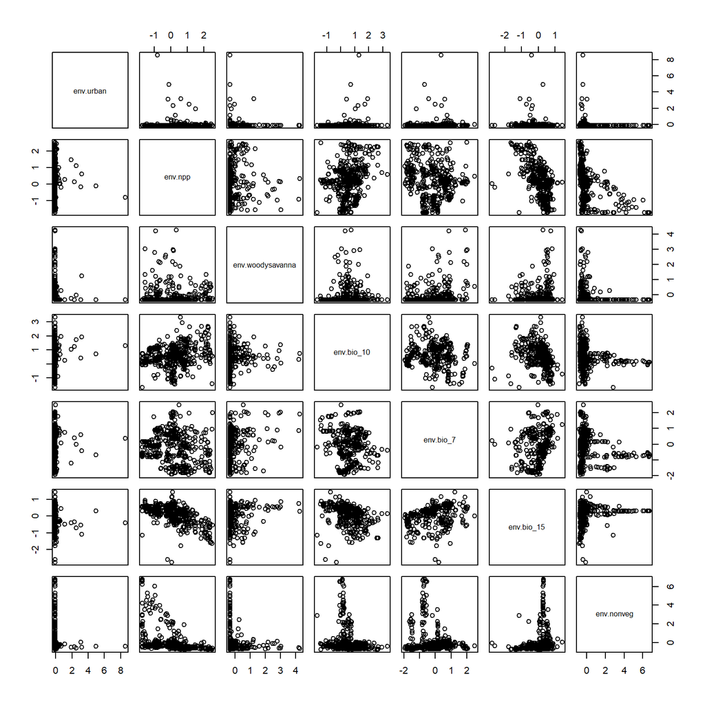

```r
selectedVariables <- unique(c(variables_brt, variables_rf, variables_ranger))

PA %>%
  filter(!if_any(everything(), is.na)) %>%
  dplyr::select(selectedVariables) %>%
  pairs()
```

```r
PA %>%
  filter(!if_any(everything(), is.na)) %>%
  dplyr::select(selectedVariables)  %>%
  cor() %>% kable()
```

|  | env.urban | env.npp | env.woodysavanna | env.bio_10 | env.bio_7 | env.bio_15 | env.nonveg |
| --- | --- | --- | --- | --- | --- | --- | --- |
| env.urban | 1.0000000 | 0.1344147 | 0.0318901 | 0.2582501 | 0.0225795 | -0.2740025 | -0.0958183 |
| env.npp | 0.1344147 | 1.0000000 | 0.0006886 | 0.2583383 | -0.2260104 | -0.6102193 | -0.4653541 |
| env.woodysavanna | 0.0318901 | 0.0006886 | 1.0000000 | 0.0182359 | 0.1850820 | 0.0462821 | -0.1058182 |
| env.bio_10 | 0.2582501 | 0.2583383 | 0.0182359 | 1.0000000 | -0.1345391 | -0.4429341 | -0.1873301 |
| env.bio_7 | 0.0225795 | -0.2260104 | 0.1850820 | -0.1345391 | 1.0000000 | 0.2496259 | -0.1488980 |
| env.bio_15 | -0.2740025 | -0.6102193 | 0.0462821 | -0.4429341 | 0.2496259 | 1.0000000 | 0.1918470 |
| env.nonveg | -0.0958183 | -0.4653541 | -0.1058182 | -0.1873301 | -0.1488980 | 0.1918470 | 1.0000000 |

```r
tmpFiles(remove=T)
```